# Final #1

Eric Hirsch

12/13/2021

## PageRank Questions

#### 1. Form the A matrix. Then, introduce decay and form the B matrix as we did in the course notes. (5 Points)

Matrix A is given in the example and can be seen as analogous to as a Markov Chain transition matrix. The problem with this matrix is that one of the nodes (2) is absorbing so there will be issues with convergence (we eventually end up at 2 no matter what.) We can handle this issue by giving the node an equal chance of ending up on any other node after you leave it. Alternatively, we could give the node higher chances of returning to one of the nodes which connects to it. I am inclined to do the former, as there would be a great deal of variability in the likelihood a page that links to your node is a page your visitors would necessarily want to visit.

```r
A <- matrix(data = c(0,.5,.5,0,0,0,
                     0,0,0,0,0,0,
                     1/3,1/3,0,0,1/3, 0,
                     0,0,0,0,.5,.5,
                     0,0,0,.5,0,.5,
                     0,0,0,1,0,0
                     ), nrow = 6, byrow=T)
A_orig <- A

A[2, ] <- rep(1/6, 6)
A
```

```
##           [,1]      [,2]      [,3]      [,4]      [,5]      [,6]
## [1,] 0.0000000 0.5000000 0.5000000 0.0000000 0.0000000 0.0000000
## [2,] 0.1666667 0.1666667 0.1666667 0.1666667 0.1666667 0.1666667
## [3,] 0.3333333 0.3333333 0.0000000 0.0000000 0.3333333 0.0000000
## [4,] 0.0000000 0.0000000 0.0000000 0.0000000 0.5000000 0.5000000
## [5,] 0.0000000 0.0000000 0.0000000 0.5000000 0.0000000 0.5000000
## [6,] 0.0000000 0.0000000 0.0000000 1.0000000 0.0000000 0.0000000
```

Now we generate B, using the .85 from the original problem.

```r
#

B <- (A*.85) + (0.15/6)
B
```

```
##           [,1]      [,2]      [,3]      [,4]      [,5]      [,6]
## [1,] 0.0250000 0.4500000 0.4500000 0.0250000 0.0250000 0.0250000
## [2,] 0.1666667 0.1666667 0.1666667 0.1666667 0.1666667 0.1666667
## [3,] 0.3083333 0.3083333 0.0250000 0.0250000 0.3083333 0.0250000
## [4,] 0.0250000 0.0250000 0.0250000 0.0250000 0.4500000 0.4500000
## [5,] 0.0250000 0.0250000 0.0250000 0.4500000 0.0250000 0.4500000
## [6,] 0.0250000 0.0250000 0.0250000 0.8750000 0.0250000 0.0250000
```

##### 2. Start with a uniform rank vector r and perform power iterations on B till convergence. That is, compute the solution r = Bn × r. Attempt this for a sufficiently large n so that r actually converges. (5 Points)

```r
# create a vector that assumes equal probability for each node
r <- c(.166667,.166667,.166667,.166667,.166667,.166667)

# Create a function to do the iterations
iterate <- function(B, r, n)
  {
    for (i in 1:n)
  {
    r <- crossprod(B, r)
  }
  return (crossprod(B, r))
}

# try out the function on different n's
iterate(B, r, 1)
```

```
##            [,1]
## [1,] 0.08245387
## [2,] 0.12318312
## [3,] 0.08934046
## [4,] 0.28118112
## [5,] 0.19342631
## [6,] 0.23041713
```

```r
iterate(B, r, 10)
```

```
##            [,1]
## [1,] 0.05190723
## [2,] 0.07403133
## [3,] 0.05764858
## [4,] 0.34830823
## [5,] 0.19979591
## [6,] 0.26831072
```

```r
iterate(B, r, 20)
```

```
##            [,1]
## [1,] 0.05170567
## [2,] 0.07368083
## [3,] 0.05741348
## [4,] 0.34870274
## [5,] 0.19990382
## [6,] 0.26859547
```

```r
iterate(B, r, 30)
```

```
##            [,1]
## [1,] 0.05170485
## [2,] 0.07367942
## [3,] 0.05741253
## [4,] 0.34870438
## [5,] 0.19990421
## [6,] 0.26859661
```

```r
iterate(B, r, 40)
```

```
##            [,1]
## [1,] 0.05170485
## [2,] 0.07367941
## [3,] 0.05741253
## [4,] 0.34870438
## [5,] 0.19990421
## [6,] 0.26859662
```

```r
iterate(B, r, 50)
```

```
##            [,1]
## [1,] 0.05170485
## [2,] 0.07367941
## [3,] 0.05741253
## [4,] 0.34870438
## [5,] 0.19990421
## [6,] 0.26859662
```

##### 3. Compute the eigen-decomposition of B and verify that you indeed get an eigenvalue of 1 as the largest eigenvalue and that its corresponding eigenvector is the same vector that you obtained in the previous power iteration method. Further, this eigenvector has all positive entries and it sums to 1.(10 points)

```r
q <- eigen(t(B))
q
```

```
## eigen() decomposition
## $values
## [1]  1.00000000+0i  0.57619235+0i -0.42500000+0i -0.42500000-0i -0.34991524+0i
## [6] -0.08461044+0i
##
## $vectors
##              [,1]          [,2]                        [,3]
## [1,] 0.1044385+0i  0.2931457+0i  2.945054e-15+5.507002e-22i
## [2,] 0.1488249+0i  0.5093703+0i -1.223015e-15-0.000000e+00i
## [3,] 0.1159674+0i  0.3414619+0i -2.241513e-15-6.032865e-22i
## [4,] 0.7043472+0i -0.5890805+0i -7.071068e-01+0.000000e+00i
## [5,] 0.4037861+0i -0.1413606+0i  7.071068e-01+0.000000e+00i
## [6,] 0.5425377+0i -0.4135367+0i  0.000000e+00-2.145851e-08i
##                             [,4]           [,5]            [,6]
## [1,]  2.945054e-15-5.507002e-22i -0.06471710+0i -0.212296003+0i
## [2,] -1.223015e-15+0.000000e+00i  0.01388698+0i  0.854071294+0i
## [3,] -2.241513e-15+6.032865e-22i  0.07298180+0i -0.363638739+0i
## [4,] -7.071068e-01+0.000000e+00i -0.66058664+0i  0.018399984+0i
## [5,]  7.071068e-01-0.000000e+00i  0.73761812+0i -0.304719509+0i
## [6,]  0.000000e+00+2.145851e-08i -0.09918316+0i  0.008182973+0i
```

The “1” eigenvalue is the first one. We need to divide the vector by its sum to normalize it - this gives us an identical vector (or nearly so) to the iterations model. Also, it has only positive values and by sums to 1 (by definition since we normalized it).

```r
v <- q$vectors[,1]
v <- v/sum(v)
v
```

```
## [1] 0.05170475+0i 0.07367926+0i 0.05741241+0i 0.34870369+0i 0.19990381+0i
## [6] 0.26859608+0i
```

```r
sum(v)
```

```
## [1] 1+0i
```

##### 4. Use the graph package in R and its page.rank method to compute the Page Rank of the graph as given in A. Note that you don’t need to apply decay. The package starts with a connected graph and applies decay internally. Verify that you do get the same PageRank vector as the two approaches above. (10 points

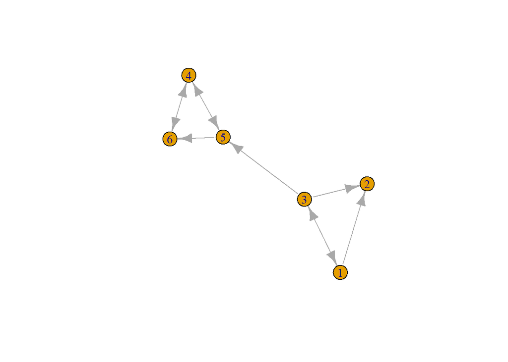

```r
library(igraph)
A_graph <- graph_from_adjacency_matrix(A_orig, weighted = TRUE, mode = "directed")
plot(A_graph)
```

```r
page_rank(A_graph)$vector
```

```
## [1] 0.05170475 0.07367926 0.05741241 0.34870369 0.19990381 0.26859608
```

We do not need to address the absorbing node (i.e. we use the original matrix) - apparently pagerank takes care of this for us. The vector is the same. We can verify this by runnng it again on the matrix which accounts for the absorbing node;

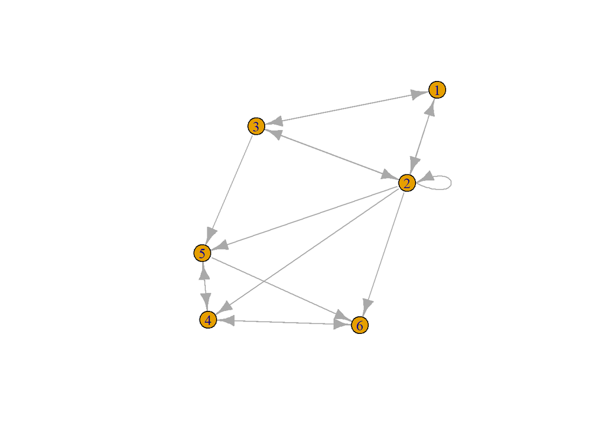

```r
A_graph <- graph_from_adjacency_matrix(A, weighted = TRUE, mode = "directed")
plot(A_graph)
```

```r
page_rank(A_graph)$vector
```

```
## [1] 0.05170475 0.07367926 0.05741241 0.34870369 0.19990381 0.26859608
```